# Resilience Survey Overview

# 8. Economics

It has been observed that communities, both rear and war affected, mostly have not redirected their special fund expenditures to other needs. However, it was found that redirection of special fund was more frequent in rear communities, as opposed to war-exposed communities.

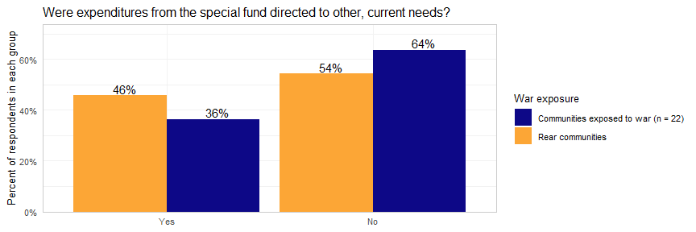

```r
d <- ds0 %>%
  mutate(
    spec_fund_relocation_fct = fct_recode(
      special_fund_relocation,
       "Yes"      = "yes"
      ,"No"       = "no"
    ) %>% factor( levels = c(
       "Yes"
       ,"No"
    )
    )
  )

d %>%
  group_by(spec_fund_relocation_fct,occupation_and_combat_fct) %>%
  summarize(
    hromada_count = n_distinct(hromada_code)
    ,.groups = "drop"
  ) %>%
  group_by(occupation_and_combat_fct) %>%
  mutate(
    prop = hromada_count/sum(hromada_count)
    ,pct = scales::percent(prop, accuracy = 1)
  ) %>%
  ggplot(aes(y=prop, x = spec_fund_relocation_fct, fill = occupation_and_combat_fct))+
  geom_col(position = position_dodge())+
  geom_text(aes(label = pct), hjust = .3, vjust = -.2, position = position_dodge(width = .9))+
  scale_y_continuous(labels = scales::percent_format(),expand = expansion(add = c(0,.1)))+
  ggplot2::scale_fill_viridis_d(begin = 0, end = .8, direction = -1, option = "plasma",guide= guide_legend(reverse=T))+
  labs(
    title = "Were expenditures from the special fund directed to other, current needs?"
    ,fill = "War exposure"
    ,y = "Percent of respondents in each group"
    ,x = NULL
  )
```

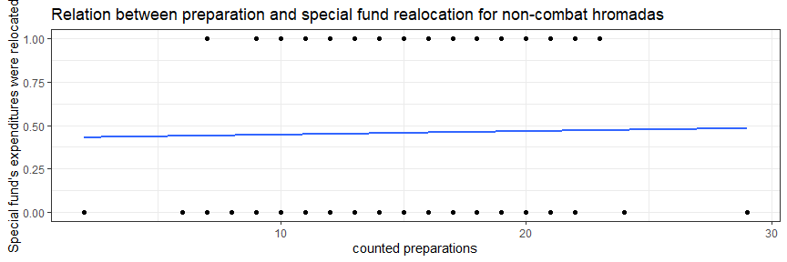

```r
(ds0 %>% filter(military_action=="no_combat") %>%
  mutate(
    `Special fund's expenditures were relocated` = case_when(special_fund_relocation=="no"~0,
                                                             special_fund_relocation=="yes"~1)
  ) %>%
  ggplot(aes(x = prep_count, y = `Special fund's expenditures were relocated`)) +
  geom_point() +
  geom_smooth(method = "lm", se=F) +
  theme_bw() +
  labs(title = 'Relation between preparation and special fund realocation for non-combat hromadas') +
  xlab("counted preparations"))
```

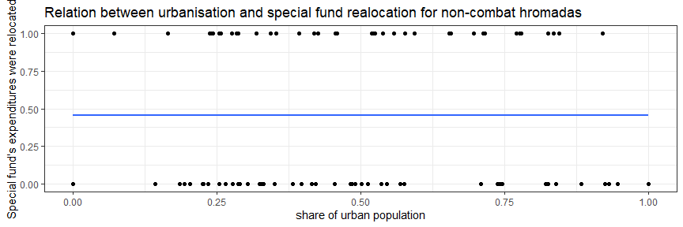

```r
(ds0 %>% filter(military_action=="no_combat") %>%
  mutate(
    `Special fund's expenditures were relocated` = case_when(special_fund_relocation=="no"~0,
                                                             special_fund_relocation=="yes"~1)
  ) %>%
  ggplot(aes(x = urban_pct, y = `Special fund's expenditures were relocated`)) +
  geom_point() +
  geom_smooth(method = "lm", se=F) +
  theme_bw() +
  labs(title = 'Relation between urbanisation and special fund realocation for non-combat hromadas') +
  xlab("share of urban population"))
```

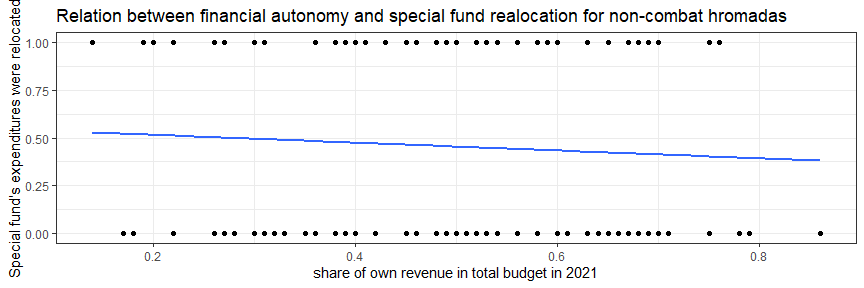

```r
(ds0 %>% filter(military_action=="no_combat") %>%
  mutate(
    `Special fund's expenditures were relocated` = case_when(special_fund_relocation=="no"~0,
                                                             special_fund_relocation=="yes"~1)
  ) %>%
  ggplot(aes(x = own_income_prop_2021, y = `Special fund's expenditures were relocated`)) +
  geom_point() +
  geom_smooth(method = "lm", se=F) +
  theme_bw() +
  labs(title = 'Relation between financial autonomy and special fund realocation for non-combat hromadas') +
  xlab("share of own revenue in total budget in 2021"))
```

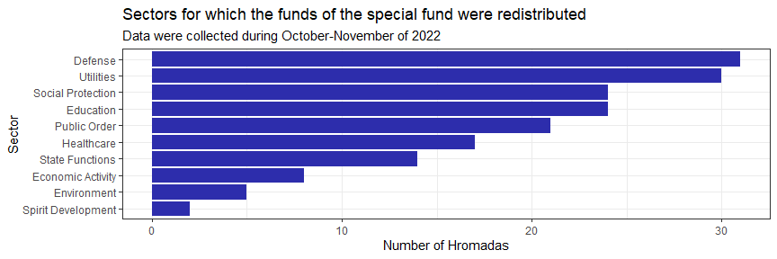

```r
ds0 %>%
  filter(special_fund_relocation == "yes") %>%
  select(hromada_name, `special_fund_relocation_needs/state_functions`:`special_fund_relocation_needs/healthcare`) %>%
  pivot_longer(-c(hromada_name), names_to = "sector", values_to = "cut") %>%
  mutate(
    sector = str_to_title(str_remove(sector, "sectors_"))
  ) %>%
  group_by(sector) %>%
  summarise(`Number of Hromadas` = sum(cut), .groups = "drop") %>%
  filter(`Number of Hromadas` > 0)  %>%
 mutate(sector = case_when(sector=="Special_fund_relocation_needs/Defense"~"Defense",
                           sector=="Special_fund_relocation_needs/Economic_activity"~"Economic Activity",
                           sector=="Special_fund_relocation_needs/Education"~"Education",
                           sector=="Special_fund_relocation_needs/Environment"~"Environment",
                           sector=="Special_fund_relocation_needs/Healthcare"~"Healthcare",
                           sector=="Special_fund_relocation_needs/Social_protection"~"Social Protection",
                           sector=="Special_fund_relocation_needs/Spirit_development"~"Spirit Development",
                           sector=="Special_fund_relocation_needs/State_functions"~"State Functions",
                           sector=="Special_fund_relocation_needs/Utilities"~"Utilities",
                           sector=="Special_fund_relocation_needs/Public_order"~"Public Order",
                           TRUE~sector)
 ) %>%
  ggplot(aes(x = `Number of Hromadas`, y = fct_reorder(sector, `Number of Hromadas`))) +
  geom_bar(stat = "identity", fill = "blue") +
  theme_bw()+
  labs(
    title = "Sectors for which the funds of the special fund were redistributed"
    ,subtitle = "Data were collected during October-November of 2022"
    ,y = "Sector"
  )+
  geom_col(position = position_stack()
           , alpha = .5
           ,data =
  )
```

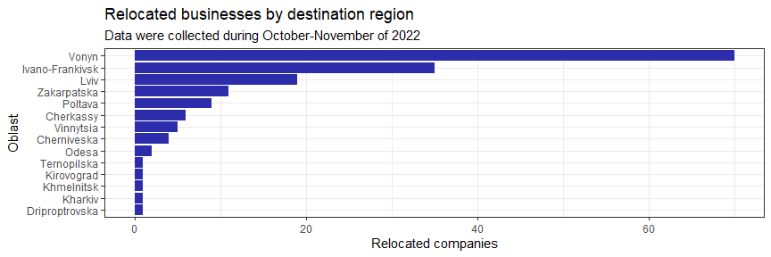

```r
ds0 %>%
  mutate(relocated_companies = as.numeric(relocated_companies_text)) %>%
      group_by(region_en,  oblast_name_en ) %>%
      summarize(`Relocated companies` = sum(relocated_companies, na.rm = TRUE)) %>%
  filter(`Relocated companies`>0) %>%
    ggplot(aes(x = `Relocated companies`, y = fct_reorder(oblast_name_en, `Relocated companies`))) +
  geom_bar(stat = "identity", fill = "blue") +
  theme_bw()+
  labs(
    title = "Relocated businesses by destination region"
    ,subtitle = "Data were collected during October-November of 2022"
    ,y = "Oblast"
  )+
  geom_col(position = position_stack()
           , alpha = .5
           ,data =
  )
```

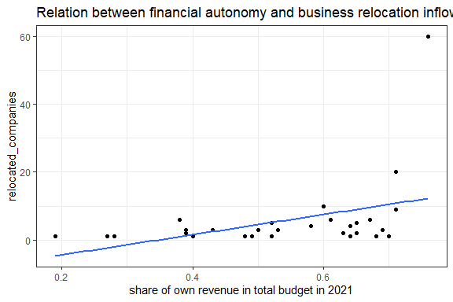

```r
ds0 %>%
  mutate(relocated_companies = as.numeric(relocated_companies_text)) %>%
  filter(relocated_companies>0) %>%
    ggplot(aes(y = relocated_companies, x = own_income_prop_2021 )) +
  geom_point() +
  geom_smooth(method = "lm", se=F) +
  theme_bw() +
  labs(title = 'Relation between financial autonomy and business relocation inflow') +
  xlab("share of own revenue in total budget in 2021")
```

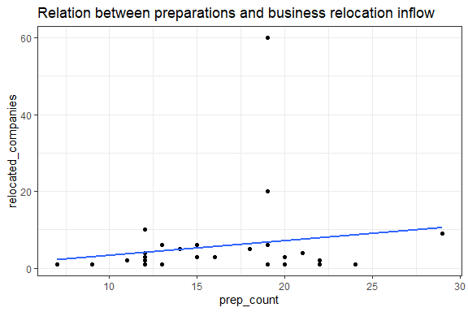

```r
ds0 %>% filter(military_action=="no_combat") %>%
  mutate(relocated_companies = as.numeric(relocated_companies_text)) %>%
  filter(relocated_companies>0) %>%
    ggplot(aes(y = relocated_companies, x = prep_count )) +
  geom_point() +
  geom_smooth(method = "lm", se=F) +
  theme_bw() +
  labs(title = 'Relation between preparations and business relocation inflow')
```

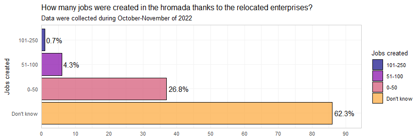

```r
(ds0 %>%
   mutate(
    `Jobs created` = fct_recode(
      created_jobs,
       "Don't know" = "dk",
      "0-50" = "0_50_jobs",
      "51-100" = "51_100_jobs",
      "101-250" = "101_250_jobs"
    ) %>% factor( levels = c(
       "Don't know"
       ,"0-50" ,
       "51-100",
       "101-250"
    )
    )
  ) %>%
   make_bi_freq_graph("Jobs created"))+
  labs(
    title = "How many jobs were created in the hromada thanks to the relocated enterprises?"
    ,subtitle = "Data were collected during October-November of 2022"
    ,y = NULL
  )
```

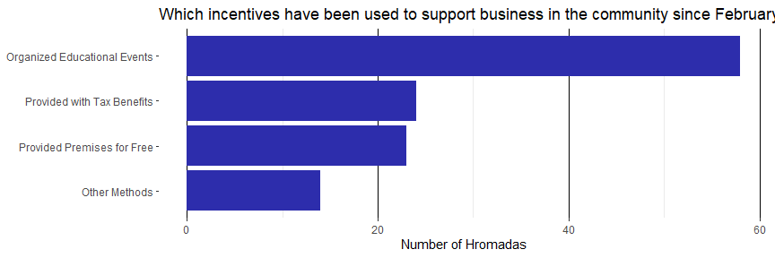

```r
ds0 %>% filter(bussiness_stimules_none == 0) %>%
  select(hromada_name, `bussiness_stimules/tax_benefits`:`bussiness_stimules/other`) %>%
  pivot_longer(-c(hromada_name), names_to = "type", values_to = "done") %>%
  mutate(
    type = str_to_title(str_remove(type, "types_"))
  ) %>%
  group_by(type) %>%
  summarise(`number of hromadas` = sum(done), .groups = "drop") %>%
  filter(`number of hromadas`>0) %>%
  mutate(type = case_when(type == "Bussiness_stimules/Education" ~ "Organized Educational Events",
                          type == "Bussiness_stimules/Free_rooms" ~ "Provided Premises for Free",
                          type == "Bussiness_stimules/Tax_benefits" ~ "Provided with Tax Benefits",
                          type == "Bussiness_stimules/Other" ~ "Other Methods",
  TRUE~type)
  ) %>%
  ggplot(aes(x = `number of hromadas`, y = fct_reorder(type, `number of hromadas`))) +
  geom_bar(stat = "identity", fill = "blue") +
  theme_bw()+
  geom_col(position = position_stack()
           , alpha = .5
           ,data =
  )+
  labs(
    title = "Which incentives have been used to support business in the community since February 24?"
    ,x = "Number of Hromadas", y = NULL, fill = NULL
  )+
  theme(
    panel.grid.major.y  = element_blank()
    ,panel.border = element_blank()
    ,panel.grid.major.x = element_line(color = "black")
  )
```

# 9. Humanitarian

# 10. Reconstructioin

small number of answers (38) - omit at this stage

## 10.1 Damage Evaluation

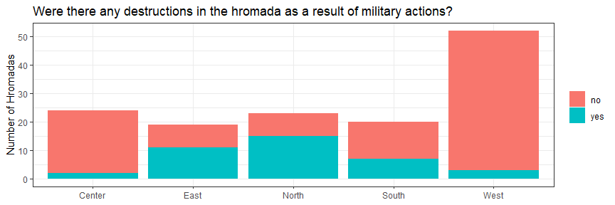

```r
ds0 %>%
  count(region_en, is_damaged) %>%
  ggplot(aes(x = region_en, y = n, fill = is_damaged)) +
  geom_bar(stat = "identity") +
  labs(
    title = "Were there any destructions in the hromada as a result of military actions?"
    ,y = "Number of Hromadas", x = NULL, fill = NULL
  ) +
  theme_bw()
```

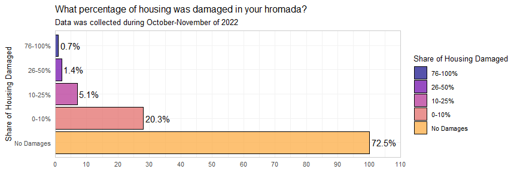

```r
(ds0 %>%
   mutate(
    `Share of Housing Damaged` = as.factor(case_when(
       is_damaged == "no" ~ "No Damages",
      percent_damaged== "0_10_percent" ~ "0-10%",
      percent_damaged== "10_25_percent" ~ "10-25%",
      percent_damaged== "26_50_percent" ~ "26-50%",
      percent_damaged== "50_75_percent" ~ "50-75%",
      percent_damaged== "76_100_percent" ~ "76-100%"
    )) %>% factor( levels = c(
       "No Damages"
       ,"0-10%" ,
       "10-25%",
       "26-50%",
       "50-75%",
       "76-100%"
    )
    )
  ) %>%
   make_bi_freq_graph("Share of Housing Damaged"))+
  labs(
    title = "What percentage of housing was damaged in your hromada?"
    ,subtitle = "Data was collected during October-November of 2022"
    ,y = NULL
  )
```

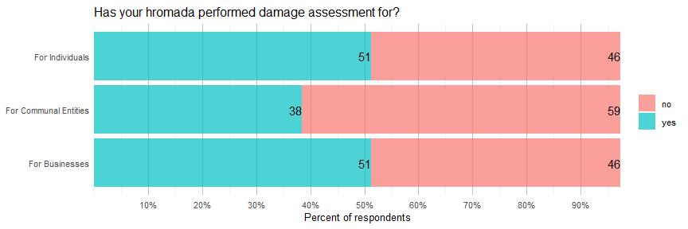

```r
d10 <-
  ds0 %>% filter(is_damaged == "yes") %>%
  pivot_longer(
    cols = c(damage_evaluation_persons, damage_evaluation_communal, damage_evaluation_bussiness)
    ,names_to = "type_of"
    ,values_to = "response"
  ) %>%
  group_by(type_of,response) %>%
  summarize(
    count = n_distinct(hromada_code)
    ,.groups = "drop"
  ) %>%
  group_by(type_of) %>%
  mutate(
    prop = count/sum(count, rm.na = T)
    ,pct = scales::percent(prop, accuracy = 1)
  ) %>%
  ungroup()  %>% mutate(type_of = case_when(type_of == "damage_evaluation_persons" ~ "For Individuals",
                                            type_of == "damage_evaluation_communal" ~ "For Communal Entities",
                                            type_of == "damage_evaluation_bussiness" ~ "For Businesses"))

g <-
  d10 %>%
  {
  ggplot(
    data = (.) %>% mutate(response=factor(response))
    ,aes(x=prop, y = type_of, fill=response)
  )+
  geom_col(position = position_stack()
           , alpha = .7
           ,data =
  )+
  geom_text(aes(label = str_remove(pct,"\\%"))
            ,hjust = 1
            , size = 4
            ,color="black"
            ,position = position_stack()
            ,data = .
            )+
  scale_x_continuous(
    breaks = seq(.1,1,.1)
    ,labels = scales::percent_format()
    ,expand = expansion(add=c(-.000,-.0))
  )+
  labs(
    title = "Has your hromada performed damage assessment for?"
    ,x = "Percent of respondents", y = NULL, fill = NULL

  )+
  theme(
    # panel.grid = element_blank()
    panel.grid.major.y  = element_blank()
    ,panel.border = element_blank()
    ,panel.grid.major.x = element_line(color = "grey")
  )
  }

g
```

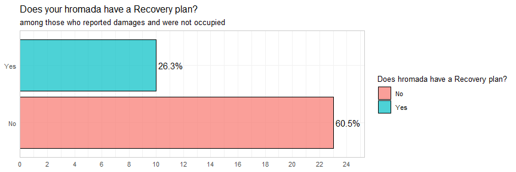

```r
(ds0 %>% mutate(`Does hromada have a Recovery plan?` = as.factor(case_when(reconstruction_plan=="yes"~"Yes",
                                                                reconstruction_plan=="no"~"No"
                                                                ))) %>% filter(is_damaged=="yes") %>% make_bi_freq_graph("Does hromada have a Recovery plan?")) +
  labs(
    title = "Does your hromada have a Recovery plan?"
    ,subtitle = "among those who reported damages and were not occupied"
    ,y = NULL, x = NULL, fill = "Does hromada have a Recovery plan?"
  ) +
  scale_x_discrete(labels=c('TRUE' = 'Yes', 'FALSE' = 'No')) +
  scale_fill_discrete(labels=c('TRUE' = 'Yes', 'FALSE' = 'No'))
```

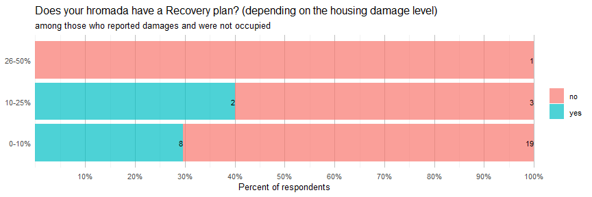

```r
ds13 <- ds0 %>% filter(!is.na(reconstruction_plan)) %>%
   mutate(
    `Share of Housing Damaged` = as.factor(case_when(
       is_damaged == "no" ~ "No Damages",
      percent_damaged== "0_10_percent" ~ "0-10%",
      percent_damaged== "10_25_percent" ~ "10-25%",
      percent_damaged== "26_50_percent" ~ "26-50%",
      percent_damaged== "50_75_percent" ~ "50-75%",
      percent_damaged== "76_100_percent" ~ "76-100%"
    )) %>% factor( levels = c(
       "No Damages"
       ,"0-10%" ,
       "10-25%",
       "26-50%",
       "50-75%",
       "76-100%"
    )
    )
  ) %>% filter(is_damaged == "yes") %>%
  group_by(`Share of Housing Damaged`, reconstruction_plan) %>%
  summarize(
    count = n()
    ,.groups = "drop"
  ) %>%
  ungroup() %>% group_by(`Share of Housing Damaged`) %>% mutate(
    prop = count/sum(count)
    ,pct = scales::percent(prop, accuracy = 1)
    )


g1 <-
  ds13 %>%
  {
  ggplot(
    data = (.)
    ,aes(x=prop, y = `Share of Housing Damaged`, fill=reconstruction_plan)
  )+
  geom_col(position = position_stack()
           , alpha = .7
           ,data =
  )+
  geom_text(aes(label = count)
            ,hjust = 1
            , size = 3
            ,color="black"
            ,position = position_stack()
            ,data = .
            )+
  scale_x_continuous(
    breaks = seq(.1,1,.1)
    ,labels = scales::percent_format()
    ,expand = expansion(add=c(-.000,-.0))
  )+
  labs(
    title = "Does your hromada have a Recovery plan? (depending on the housing damage level)"
    ,subtitle = "among those who reported damages and were not occupied"
    ,x = "Percent of respondents", y = NULL, fill = NULL

  )+
  theme(
    # panel.grid = element_blank()
    panel.grid.major.y  = element_blank()
    ,panel.border = element_blank()
    ,panel.grid.major.x = element_line(color = "grey")
  )
  }

g1
```

# 11. Current Challenges

```r
# ds0 %>%
#   count(region_en, is_damaged) %>%
#   ggplot(aes(x = region_en, y = n, fill = is_damaged)) +
#   geom_bar(stat = "identity") +
#   labs(
#     title = "Were there any destructions in the community as a result of military actions?"
#     ,y = "Number of Hromadas", x = NULL, fill = NULL
#   ) +
#   theme_bw()
```

#poor quality of answerts regarding days without schooling - consider to omit at all

## 11.1 Heating season

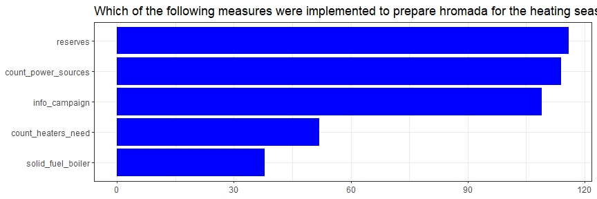

```r
ds1_winter_prep %>%
  select(hromada_name, all_of(prep_for_winter)) %>%
  pivot_longer(
    -hromada_name
    ,names_to = "action"
    ,values_to = "response"
  ) %>%
  group_by(action) %>%
  summarise(n = sum(response, na.rm = T), .groups = "drop") %>%
  ggplot(aes(x = n, y = fct_reorder(action, n))) +
  geom_bar(stat = "identity", fill = "blue") +
  labs(
    title = "Which of the following measures were implemented to prepare hromada for the heating season?"
    ,y = NULL, x = NULL, fill = NULL
  ) +
  theme_bw()
```

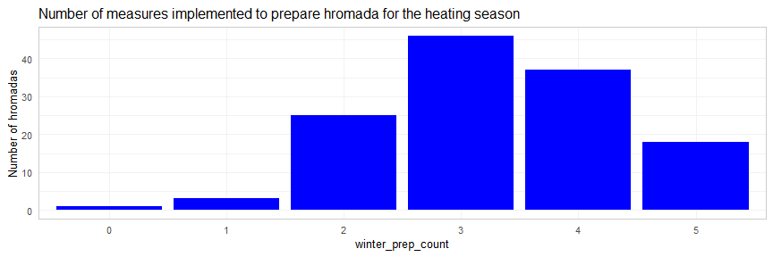

```r
ds1_winter_prep %>%
  count(winter_prep_count) %>%
  filter(!is.na(winter_prep_count)) %>%
  ggplot(aes(x = factor(winter_prep_count), y = n)) +
  geom_bar(stat = "identity", fill = "blue") +
  labs(
    title = "Number of measures implemented to prepare hromada for the heating season"
    ,y = "Number of hromadas", x = "Number of measures", fill = NULL
  ) +
  xlab("winter_prep_count")
```

```r
m1_heating <-lm(data = ds1_winter_prep,
       winter_prep_count ~ log(income_total_2021) + own_income_prop_2021 +
         type + square + log(total_population_2022) + urban_pct + n_settlements + region_en + occupation + military_action + voluntary)

m2_heating <-lm(data = ds1_winter_prep,
             winter_prep_count ~ log(income_total_2021) + own_income_prop_2021 +
               turnout_2020 + travel_time +
               type + square + log(total_population_2022) + urban_pct + n_settlements + region_en + occupation + military_action + voluntary)

m3_heating <-lm(data = ds1_winter_prep,
             winter_prep_count ~ log(income_total_2021) + own_income_prop_2021 +
               turnout_2020 + + travel_time +
               type + square + log(total_population_2022) + urban_pct + n_settlements + region_en + occupation + military_action + voluntary +
               sex_head + age_head + education_head + incumbent + rda)

m4_heating <-lm(data = ds1_winter_prep,
             winter_prep_count ~ log(income_total_2021) + own_income_prop_2021 +
               turnout_2020 + + travel_time +
               type + square + log(total_population_2022) + urban_pct + n_settlements + region_en + occupation + military_action + voluntary +
               sex_head + age_head + education_head + incumbent + rda +
               youth_councils + youth_centers + region_en * sum_osbb_2020)


stargazer::stargazer(m1_heating, m2_heating, m3_heating, m4_heating, single.row = T, type = 'html')
```

|  | *Dependent variable:* |  |  |  |
| --- | --- | --- | --- | --- |
|  | winter_prep_count |  |  |  |
|  | (1) | (2) | (3) | (4) |
| log(income_total_2021) | -0.041 (0.608) | 0.091 (0.609) | -0.155 (0.632) | 1.041 (0.908) |
| own_income_prop_2021 | -0.797 (1.098) | -1.270 (1.114) | -0.947 (1.152) | -2.188 (1.577) |
| turnout_2020 |  | 3.298* (1.724) | 3.437* (1.771) | 6.324*** (2.251) |
| travel_time |  | 0.002 (0.002) | 0.003 (0.002) | 0.005* (0.003) |
| typeurban village | -0.115 (0.421) | -0.251 (0.422) | -0.174 (0.432) | -0.979 (0.724) |
| typeurban | -0.337 (0.561) | -0.494 (0.560) | -0.407 (0.583) | -1.489* (0.867) |
| square | 0.0002 (0.001) | -0.0001 (0.001) | 0.00000 (0.001) | 0.0001 (0.001) |
| log(total_population_2022) | 0.202 (0.619) | 0.310 (0.619) | 0.599 (0.642) | -0.240 (0.877) |
| urban_pct | -0.110 (0.771) | 0.169 (0.774) | -0.004 (0.804) | 0.514 (1.050) |
| n_settlements | 0.001 (0.010) | 0.003 (0.010) | 0.0004 (0.010) | -0.010 (0.011) |
| region_enEast | 0.206 (0.344) | 0.427 (0.351) | 0.442 (0.357) | -0.015 (0.648) |
| region_enNorth | 0.372 (0.413) | 0.322 (0.411) | 0.298 (0.417) | 1.285 (0.799) |
| region_enSouth | -0.521 (0.397) | -0.542 (0.396) | -0.548 (0.400) | 0.508 (0.972) |
| region_enWest | 0.176 (0.359) | 0.022 (0.378) | 0.072 (0.394) | -0.256 (0.503) |
| occupationoccupied_april | -0.296 (0.576) | -0.439 (0.572) | -0.448 (0.592) | -1.404 (1.283) |
| military_actioncombat_now | 0.136 (0.710) | 0.246 (0.701) | 0.197 (0.708) | -0.709 (1.097) |
| military_actionno_combat | 0.196 (0.612) | 0.075 (0.605) | -0.006 (0.628) | -0.628 (1.525) |
| voluntary | -0.042 (0.209) | 0.047 (0.213) | 0.036 (0.217) | -0.151 (0.279) |
| sex_headmale |  |  | 0.056 (0.230) | -0.052 (0.326) |
| age_head |  |  | -0.008 (0.012) | -0.011 (0.018) |
| education_headnon-higher |  |  | 0.399 (0.418) | 0.315 (0.546) |
| incumbent |  |  | 0.191 (0.224) | 0.087 (0.302) |
| rda |  |  | -0.489 (0.423) | 0.073 (0.485) |
| youth_councils |  |  |  | -0.075 (0.488) |
| youth_centers |  |  |  | -0.103 (0.299) |
| sum_osbb_2020 |  |  |  | 0.009 (0.020) |
| region_enEast:sum_osbb_2020 |  |  |  | 0.027 (0.034) |
| region_enNorth:sum_osbb_2020 |  |  |  | -0.035 (0.024) |
| region_enSouth:sum_osbb_2020 |  |  |  | -0.211** (0.089) |
| region_enWest:sum_osbb_2020 |  |  |  | -0.006 (0.019) |
| Constant | 2.330 (5.461) | -2.222 (5.805) | -0.445 (6.080) | -12.656 (8.927) |
| Observations | 130 | 129 | 129 | 72 |
| R<sup>2</sup> | 0.089 | 0.136 | 0.168 | 0.546 |
| Adjusted R<sup>2</sup> | -0.040 | -0.006 | -0.014 | 0.213 |
| Residual Std. Error | 1.075 (df = 113) | 1.059 (df = 110) | 1.064 (df = 105) | 0.916 (df = 41) |
| F Statistic | 0.691 (df = 16; 113) | 0.958 (df = 18; 110) | 0.923 (df = 23; 105) | 1.641* (df = 30; 41) |
| *Note:* | p<0.1; p<0.05; p<0.01 |  |  |  |

## 11.2 Problem Involvement

```r
m1_problem <-glm(data = ds1_problem,
             hromada_exp ~ log(income_total_2021) + own_income_prop_2021 +
             type + square + log(total_population_2022) + urban_pct + n_settlements + region_en + occupation + military_action + voluntary,
             family = "binomial")

m2_problem  <-glm(data = ds1_problem,
             hromada_exp ~ log(income_total_2021) + own_income_prop_2021 +
               turnout_2020 + travel_time +
               type + square + log(total_population_2022) + urban_pct + n_settlements + region_en + occupation + military_action + voluntary,
             family = "binomial")

m3_problem  <-glm(data = ds1_problem,
             hromada_exp ~ log(income_total_2021) + own_income_prop_2021 +
               turnout_2020 + + travel_time +
               type + square + log(total_population_2022) + urban_pct + n_settlements + region_en + occupation + military_action + voluntary +
               sex_head + age_head + education_head + incumbent + rda,
             family = "binomial")

m4_problem  <-glm(data = ds1_problem,
             hromada_exp ~ log(income_total_2021) + own_income_prop_2021 +
               turnout_2020 + + travel_time +
               type + square + log(total_population_2022) + urban_pct + n_settlements + region_en + occupation + military_action + voluntary +
               sex_head + age_head + education_head + incumbent + rda +
               youth_councils + youth_centers + region_en * sum_osbb_2020,
             family = "binomial")

stargazer::stargazer(m1_problem, m2_problem, m3_problem, m4_problem, single.row = T, type = 'html')
```

|  | *Dependent variable:* |  |  |  |
| --- | --- | --- | --- | --- |
|  | hromada_exp |  |  |  |
|  | (1) | (2) | (3) | (4) |
| log(income_total_2021) | 0.135 (1.503) | 0.093 (1.517) | -0.736 (1.677) | -84.725 (692,099.900) |
| own_income_prop_2021 | 0.107 (2.818) | 0.181 (2.838) | 1.581 (2.970) | 114.139 (730,084.900) |
| turnout_2020 |  | -0.826 (4.510) | -2.146 (4.699) | 135.893 (2,141,099.000) |
| travel_time |  | 0.002 (0.005) | 0.001 (0.005) | -0.343 (3,853.388) |
| typeurban village | 1.061 (1.127) | 1.019 (1.146) | 1.402 (1.230) | -4.701 (819,133.200) |
| typeurban | 0.307 (1.459) | 0.174 (1.477) | 0.566 (1.571) | -27.317 (1,039,895.000) |
| square | -0.003** (0.002) | -0.003** (0.002) | -0.003* (0.002) | -0.060 (265.870) |
| log(total_population_2022) | 0.459 (1.513) | 0.516 (1.557) | 1.281 (1.709) | 125.880 (495,023.100) |
| urban_pct | -0.679 (2.098) | -0.732 (2.123) | -1.165 (2.271) | 7.480 (1,382,325.000) |
| n_settlements | 0.048 (0.030) | 0.054* (0.032) | 0.050 (0.033) | 0.270 (14,526.640) |
| region_enEast | 1.519 (1.175) | 1.595 (1.187) | 1.294 (1.218) | 29.804 (367,404.000) |
| region_enNorth | 0.529 (1.207) | 0.600 (1.224) | 0.461 (1.263) | 56.732 (691,508.000) |
| region_enSouth | 0.383 (0.936) | 0.486 (0.949) | 0.395 (0.971) | -45.057 (371,854.300) |
| region_enWest | -0.103 (0.893) | 0.062 (0.947) | 0.187 (1.025) | 32.596 (512,285.700) |
| occupationoccupied_april | -1.840 (1.633) | -1.811 (1.649) | -1.800 (1.712) | -25.166 (621,634.500) |
| occupationoccupied_august | -19.982 (3,956.181) | -20.257 (3,956.181) | -21.439 (6,522.639) |  |
| occupationoccupied_now | -1.855 (1.777) | -1.854 (1.803) | -1.905 (1.884) | -49.613 (460,278.900) |
| military_actioncombat_now | -16.271 (1,403.286) | -16.298 (1,402.541) | -17.289 (2,250.865) | -43.202 (606,589.200) |
| military_actionno_combat | -17.568 (1,403.286) | -17.583 (1,402.541) | -18.544 (2,250.864) | 37.331 (652,535.300) |
| voluntary | 0.614 (0.578) | 0.691 (0.591) | 0.901 (0.641) | 42.242 (212,131.500) |
| sex_headmale |  |  | -0.026 (0.640) | -7.225 (289,236.300) |
| age_head |  |  | -0.036 (0.034) | -4.669 (29,066.870) |
| education_headnon-higher |  |  | 17.630 (1,980.788) | 15.497 (478,058.400) |
| incumbent |  |  | 0.421 (0.592) | -34.180 (285,656.300) |
| rda |  |  | -0.308 (1.097) | -19.316 (352,081.200) |
| youth_councils |  |  |  | 31.807 (358,561.700) |
| youth_centers |  |  |  | 5.807 (252,011.000) |
| sum_osbb_2020 |  |  |  | 0.133 (9,351.328) |
| region_enEast:sum_osbb_2020 |  |  |  | 1.884 (20,336.010) |
| region_enNorth:sum_osbb_2020 |  |  |  | -0.734 (24,690.320) |
| region_enSouth:sum_osbb_2020 |  |  |  | -0.171 (10,036.550) |
| region_enWest:sum_osbb_2020 |  |  |  | -0.917 (9,813.355) |
| Constant | 11.849 (1,403.349) | 12.078 (1,402.611) | 21.914 (2,250.919) | 498.071 (7,397,994.000) |
| Observations | 137 | 136 | 136 | 75 |
| Log Likelihood | -54.208 | -53.722 | -50.852 | -0.000 |
| Akaike Inf. Crit. | 146.415 | 149.444 | 153.703 | 64.000 |
| *Note:* | p<0.1; p<0.05; p<0.01 |  |  |  |

```r
meta_survey %>% filter(group=="preparation") %>% pull(name)
```

```
 [1] "prep_first_aid_water"            "prep_first_aid_fuel"
 [3] "prep_reaction_plan"              "prep_evacuation_plan"
 [5] "prep_reaction_plan_oth_hromadas" "prep_reaction_plan_oda"
 [7] "prep_dftg_creation"              "prep_national_resistance"
 [9] "prep_starosta_meeting"           "prep_communal_meetiing"
[11] "prep_online_map"                 "prep_shelter_list"
[13] "prep_notification_check"         "prep_backup"
[15] "prep_partly_backup"
```

# Session Information

Report rendered by Valentyn Hatsko at 2023-02-01, 13:27 +0200 in 25 seconds.